# R DataMining & Data Viz’

Nous avons aussi décidé de fusionné des catégories entres elles. Pour la couleur, “grey” et “silver”, et pour la condition “like_new” et “new”.

```r
######### paint_color #########
# ==> fusion modalité grey et silver et remplacer NaN par "Not Documented"

data_new$paint_color= recode(data_new$paint_color, silver= "grey")
data_new$paint_color= as.character(data_new$paint_color)
data_new$paint_color[is.na(data_new$paint_color)]= "Not Documented"
data_new$paint_color= as.factor(data_new$paint_color)
data_new$paint_color = droplevels(data_new$paint_color)
unique(data_new$paint_color)
```

```
##  [1] blue           Not Documented white          black          grey
##  [6] brown          green          red            orange         yellow
## [11] custom         purple
## 12 Levels: black blue brown custom green grey Not Documented orange ... yellow
```

```r
######### size #########
# ==> manque des classes dans le segment automobile (classe A B C ... F)
#on va remplacer NaN par "Not Documented"
#ou on peut droper
data_new$size= as.character(data_new$size)
data_new$size[is.na(data_new$size)]= "Not Documented"
data_new$size= as.factor(data_new$size)
data_new$size = droplevels(data_new$size)
unique(data_new$size)
```

```
## [1] mid-size       Not Documented compact        full-size      sub-compact
## Levels: compact full-size mid-size Not Documented sub-compact
```

```r
######### drive #########
#pattern de valeur manquante entre condition, drive, type
#drive ==> remplacement NaN par "awd" (autre type de drive) (courant aux US)
data_new$drive= as.character(data_new$drive)
data_new$drive[is.na(data_new$drive)]= "Not Documented"
data_new$drive= as.factor(data_new$drive)
data_new$drive = droplevels(data_new$drive)
unique(data_new$drive)
```

```
## [1] rwd            Not Documented 4wd            fwd
## Levels: 4wd fwd Not Documented rwd
```

```r
######### type #########
data_new$type= as.character(data_new$type)
data_new$type[is.na(data_new$type)]= "Not Documented"
data_new$type= as.factor(data_new$type)
data_new$type = droplevels(data_new$type)
unique(data_new$type)
```

```
##  [1] coupe          Not Documented sedan          wagon          hatchback
##  [6] SUV            truck          pickup         van            mini-van
## [11] other          convertible    bus            offroad
## 14 Levels: bus convertible coupe hatchback mini-van Not Documented ... wagon
```

```r
######### condition #########
data_new$condition= recode(data_new$condition, new= "like new")
data_new$condition= as.character(data_new$condition)
data_new$condition[is.na(data_new$condition)]= "Not Documented"
data_new$condition= as.factor(data_new$condition)
data_new$condition = droplevels(data_new$condition)
unique(data_new$condition)
```

```
## [1] good           Not Documented excellent      like new       fair
## [6] salvage
## Levels: excellent fair good like new Not Documented salvage
```

```r
######### cylinders #########
# pas sûr par cete transformation
data_new$cylinders= as.character(data_new$cylinders)
data_new$cylinders[is.na(data_new$cylinders)]= "Not Documented"
data_new$cylinders= as.factor(data_new$cylinders)
data_new$cylinders = droplevels(data_new$cylinders)
unique(data_new$cylinders)
```

```
## [1] 6 cylinders    Not Documented 4 cylinders    8 cylinders    5 cylinders
## [6] other          3 cylinders    10 cylinders   12 cylinders
## 9 Levels: 10 cylinders 12 cylinders 3 cylinders 4 cylinders ... other
```

```r
######### year #########
data_new$year= as.factor(data_new$year)#on passe en factor au cas ou
data_new$year= retraitement(data_new$year)
data_new$year= as.numeric(as.character(data_new$year))
mean(is.na(data_new$year)) #vérification
```

```
## [1] 0
```

```r
######### odometer #########
data_new$odometer= retraitement(data_new$odometer)

######### make #########
data_new$make= retraitement(data_new$make)

######### fuel #########
data_new$fuel= retraitement(data_new$fuel)

######### title #########
data_new$title_status= retraitement(data_new$title_status)

######### transmission #########
data_new$transmission= retraitement(data_new$transmission)
```

Vérification

```r
#la verificaiton
navar= colSums(is.na(data_new))/nrow(data_new) #taux de na dans les colonnes (variable)
navar
```

```
##          url         city     city_url        price         year manufacturer
## 0.000000e+00 0.000000e+00 0.000000e+00 0.000000e+00 0.000000e+00 0.000000e+00
##         make    condition    cylinders         fuel     odometer title_status
## 0.000000e+00 0.000000e+00 0.000000e+00 0.000000e+00 0.000000e+00 0.000000e+00
## transmission          VIN        drive         size         type  paint_color
## 0.000000e+00 4.107492e-01 0.000000e+00 0.000000e+00 0.000000e+00 0.000000e+00
##    image_url         desc          lat         long
## 0.000000e+00 2.699633e-05 2.281383e-02 2.281383e-02
```

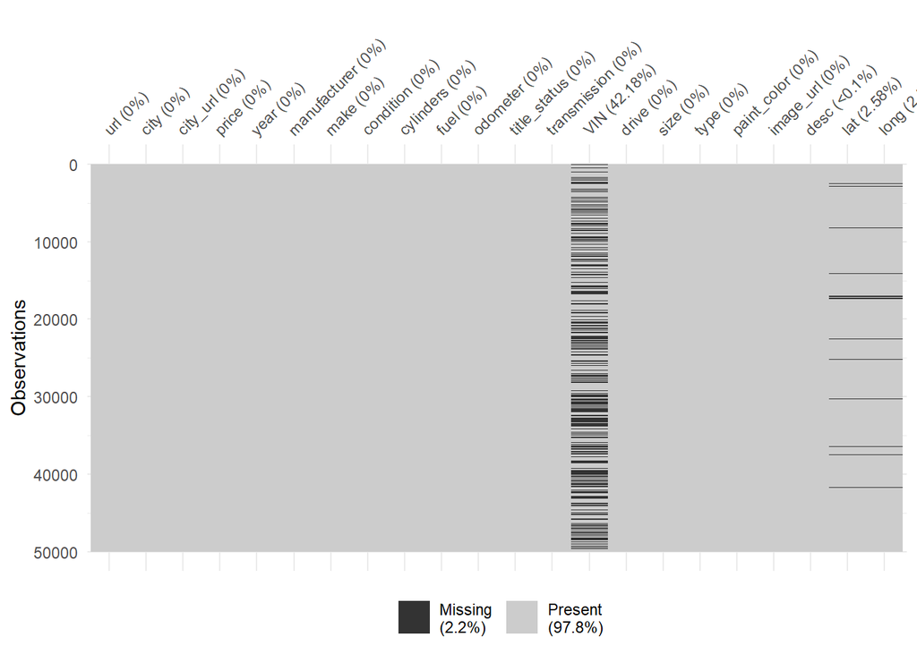

```r
vis_miss(setDT(data_new)[c(0:50000)], warn_large_data=F)
```

Traitement des Outliers

```r
#ces décisions proviennent de l'analyse précédente
data_abe= copy(data_new)
data_abe= data_abe %>% filter(year <= 2019
                              , year >= 1950
                              , odometer <= 999999
                              , price > 0
                              , price <= 250000)
#, long >= -180  #limite US
#, long <= -66.9
#, lat >= 5.87
#, lat <= 71.39) #ca a drop les NaN de lat et long

#summary(data_abe)
dim(data_abe)
```

```
## [1] 469166     22
```

```r
rm(data)
rm(data_new)
rm(nums)
rm(quali)
```

## *Feature engineering*

Ici, nous allons à la fois: - traiter les outliers de lat et long en prenant la moyenne des lat long par ville - associer à nos villes un Etats américain (le plus proche) - et enfin, supprimer les doublons

De plus, la variable Etat ne sera pas utiliser dans la suite de l’analyse, mais nous permettra de tracer de belles cartes sur Tableau !

Nous allons creer un nouveau dataset, mais on ne l’utilisera pas dans le cadre de l’analyse. C’est cette table que nous utiliserons pour faire une jointure sur Tableau

```r
##################################################################################
##                                CREATION VARIABLES                            ##
##################################################################################


#on modifie la valeurs des lat / long par la moyenne des lat / long par ville
data_general_localisation= aggregate(data_abe[, 21:22]
                                     , list(data_abe$city)
                                     , mean
                                     , na.rm= TRUE)
#on associe nos nouvelles valeurs de lat / long à notre dataset initial
data_merge= merge(data_abe, data_general_localisation, by.x= "city", by.y= "Group.1")
data_merge$lat.x= NULL
data_merge$long.x= NULL
data_merge$url= NULL
data_merge$city_url= NULL
data_merge$VIN=NULL
data_merge$desc= NULL
data_merge$image_url= NULL
colnames(data_merge)[colnames(data_merge) == 'lat.y'] <- 'lat'
colnames(data_merge)[colnames(data_merge) == 'long.y'] <- 'long'
data_abe= data_merge
rm(data_merge)

#
#suppression doublons
#
dim(data_abe)
```

```
## [1] 469166     17
```

```r
data_abe= data_abe[!duplicated(data_abe), ]
dim(data_abe)
```

```
## [1] 414822     17
```

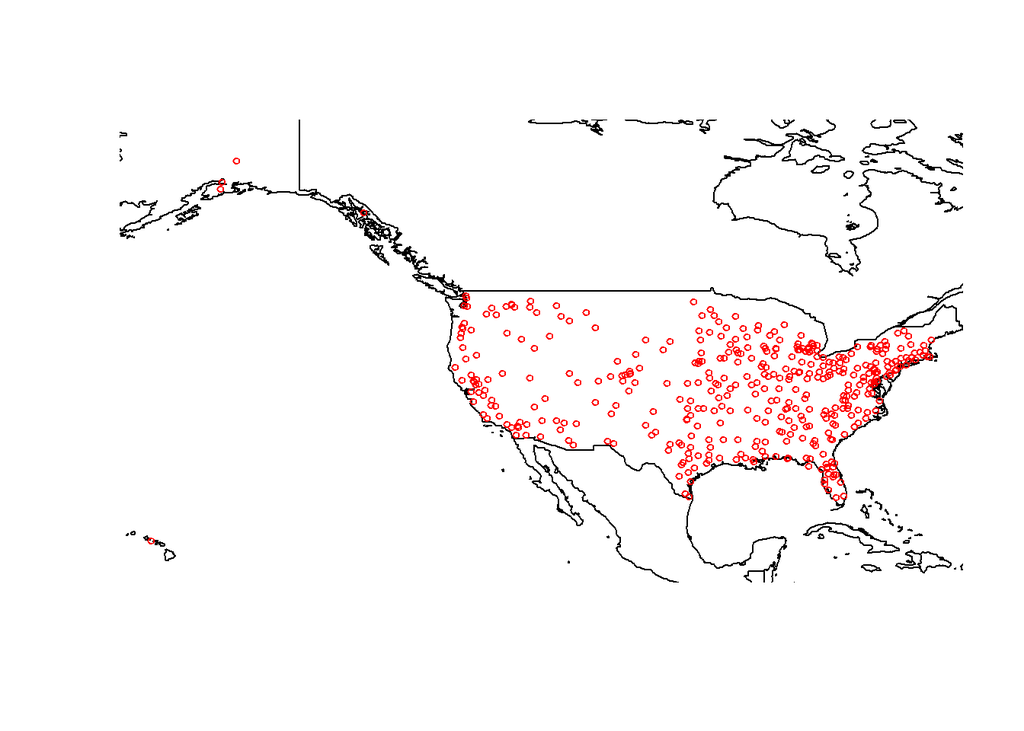

```r
#
#on va plot nos coordonnées pour voir
#

newmap <- getMap(resolution = "low")
xlim= c(min(data_general_localisation$long, na.rm=T), max(data_general_localisation$long, na.rm=T)) #long
ylim= c(min(data_general_localisation$lat, na.rm=T), max(data_general_localisation$lat, na.rm=T)) #lat
plot(newmap, xlim = xlim, ylim = ylim, asp = 1)
points(data_general_localisation$long, data_general_localisation$lat, col = "red", cex = .6)
```

```r
# on remarque que le fait d'aggréger nos lat / long a supprimé nos valeurs aberrantes


#on va chercher à déterminer de quel ville US, la ville dans notre DF se rapproche le plus
#(utilisation des lat / long de data_general_localisation)

localisation_us= read.csv("data/us-zip-code-latitude-and-longitude.csv", sep= ";")
dim(localisation_us)
```

```
## [1] 43191     8
```

```r
localisation_us$geopoint= NULL
localisation_us$Timezone= NULL
localisation_us$Zip= NULL
localisation_us$Daylight.savings.time.flag= NULL

#on a plusieurs fois la même ville avec des coordonnéees uasi égale (différence liéau zip code qu'on a delete)
#on va donc faire récupérer la première occurence par ville (1er ligne)

#d'abord on range par ordre de ville ET d'état
localisation_us= localisation_us[order(localisation_us$City, localisation_us$State),]
#puis on supprime les dupliquées
localisation_us= localisation_us[!duplicated(localisation_us[c(1, 2)]),]
dim(localisation_us)
```

```
## [1] 30346     4
```

```r
#on a enfin des données de ville / etat exploitable
#maintenant on va s'amuser à chercher la ville qui est la plus proche des coordonnées
#que nous avons calculé pour lui associé un Etat (pour la partie Tableau)

#trouvé sur internet
#permet de faire un merge par rapport à la distance minimale
greatCircleDistance <- function(lat1, long1, lat2, long2, radius=6372.795){
  sf <- pi/180
  lat1 <- lat1*sf
  lat2 <- lat2*sf
  long1 <- long1*sf
  long2 <- long2*sf
  lod <- abs(long1-long2)
  radius * atan2(
    sqrt((cos(lat1)*sin(lod))**2 +
           (cos(lat2)*sin(lat1)-sin(lat2)*cos(lat1)*cos(lod))**2),
    sin(lat2)*sin(lat1)+cos(lat2)*cos(lat1)*cos(lod)
  )
}


dist.merge <- function(x, y, xlongnme, xlatnme, ylongnme, ylatnme){
  tmp <- t(apply(x[,c(xlongnme, xlatnme)], 1, function(x, y){
    dists <- apply(y, 1, function(x, y) greatCircleDistance(x[2],
                                                            x[1], y[2], y[1]), x)
    cbind(1:nrow(y), dists)[dists == min(dists),,drop=F][1,]
  }
  , y[,c(ylongnme, ylatnme)]))
  tmp <- cbind(x, min.dist=tmp[,2], y[tmp[,1],-match(c(ylongnme,
                                                       ylatnme), names(y))])
  row.names(tmp) <- NULL
  tmp
}

#attention c'est un peu long
data_merge_localisation= dist.merge(data_general_localisation
                                    , localisation_us
                                    , 'long', 'lat', 'Longitude', 'Latitude')
#on change le nom de nos features
data_merge_localisation= data_merge_localisation %>%
  dplyr::rename(city_neighbour= City, city= Group.1)
```

### Remarque:

On enregistre les tables pour l’analyse et la partie Tableau (les Etats).

```r
write.csv(data_merge_localisation
          , file = "data_merge_localisation.csv")


#DATASET FINAL A RECUPERER !!!!!!!!!!!!!!!! #
write.csv(data_abe
          , file = "data_abe.csv")
```